# Innovation partnerships for (green) development

Innovation partnerships for  
(green) development

Ralf Martin (Imperial College London)  
with Samuel Edet, Golvine de Rochambeau, Trang Thu Tran and Dennis Verhoeven

[figure not shown]

Hitachi — November 2026

## Innovation matters — but little of it happens in EMDE

- **Innovation is the key to economic growth** — and essential for the big problems of our time, climate change above all
- Yet **very little of the world’s innovation happens in Emerging and Developing Economies (EMDE)**: only **4%** of the 6.8 million innovations of 2013–2022 involve an EMDE inventor
- Two basic reasons are usually given:

**1. Quality:** innovation in EMDE is of lower quality than in high-income countries (HIC)

**2. Resources:** fewer researchers, less R&D finance, smaller firms

[figure not shown]

Evidence from **PATSTAT 2025** — 6.8M patent families 2013–2022, each valued by its knowledge spillovers (Patent Rank) — in [CEP DP 2223](https://cep.lse.ac.uk/pubs/download/dp2223.pdf) and the IFC report *Innovation in Green Technologies*

## Lower quality on average — but not all of it

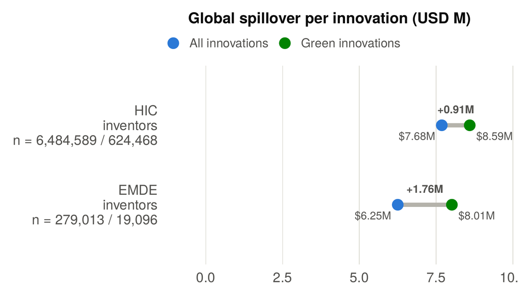

**True on average:** an EMDE innovation generates **$6.3M** of knowledge spillover vs **$7.7M** for a HIC innovation (−19%)

**Key insight: green innovation — climate mitigation and adaptation — is of particularly high quality.** Green adds +$0.9M per innovation for HIC inventors (+12%) and **+$1.8M for EMDE inventors (+28%)**

**Green EMDE innovations are as good as the average innovation anywhere:** $8.0M vs $7.6M

## Patent Rank (from Page to Patent Rank)

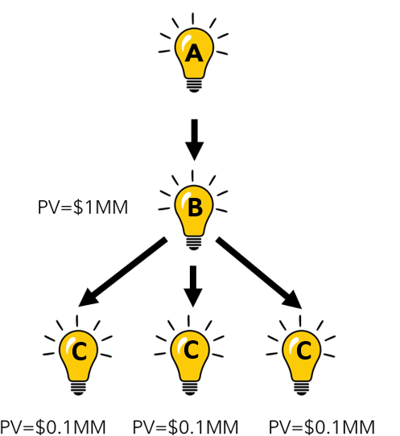

**Page**Rank:

$PageRank_i = \alpha\frac{1}{\#(Webpages)} + \sum_{j\in B(i)} \phi_{ij}\,PageRank_j$

**Patent**Rank:

$PRANK_i = PrivateValue_i + \sum_{j\in B(i)} \phi_{ij}\,PRANK_j$

where $\;\phi_{ij} = \sigma\times\dfrac{1}{\text{Backward cites of } j}$

**Social** value of innovation *i*

**Private** value of innovation *i*: stock-market reaction to the patent grant (Kogan et al. 2017), extended to all patent offices (Guillard et al. 2021)

Contribution of innovation *i* to the value of innovation *j*

Assumptions:  
• all backward cites have the same contribution  
• contribution smaller if a patent cites many

## How do EMDE innovators manage this? Collaboration

EMDE–HIC collaboration With Chinese inventor Same income group National only

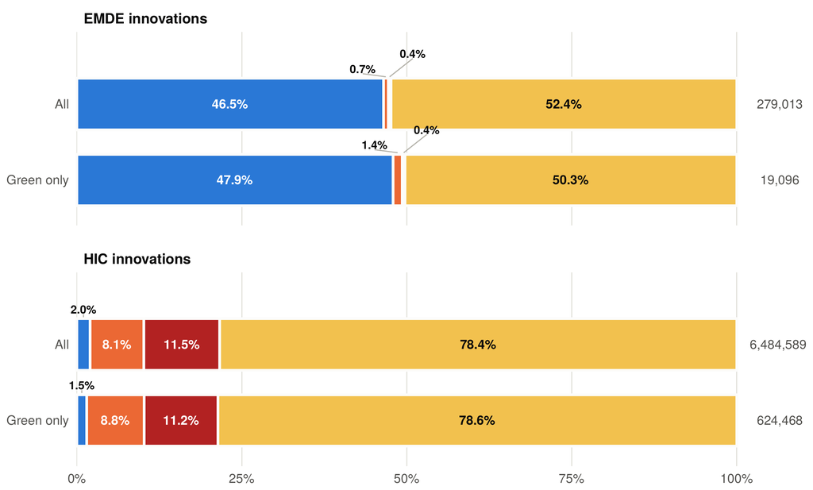

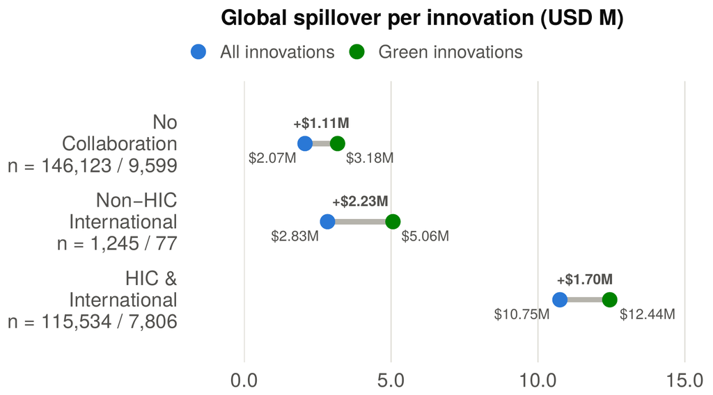

**Nearly half (46.5%) of all EMDE innovations** are collaborations with HIC inventors (47.9% for green)

**The view from HIC:** EMDE inventors appear in only **2.0%** of HIC innovations — 78% are purely national

**And these collaborations are the high-quality ones:** $10.8M of global spillover per innovation ($12.4M green) — **five times** the $2.1M of EMDE innovations without international collaboration

## Would more HIC–EMDE collaboration be a good idea?

Two possible reasons against:

**1. Diversion** — it could pull EMDE innovators away from the problems that matter for EMDE

**2. Dilution** — good for EMDE, but it might compromise the innovation impact for HIC, or globally

- Half of all HIC–EMDE collaborative innovations involve one of these firms — yet, as a group, they do only **2.2%** of their innovations with EMDE inventors (77% of firms: none at all)
- Question: do firms with a more EMDE-diverse inventor base generate more or less knowledge spillover per innovation?

[figure not shown]

## A diversification premium — a win–win

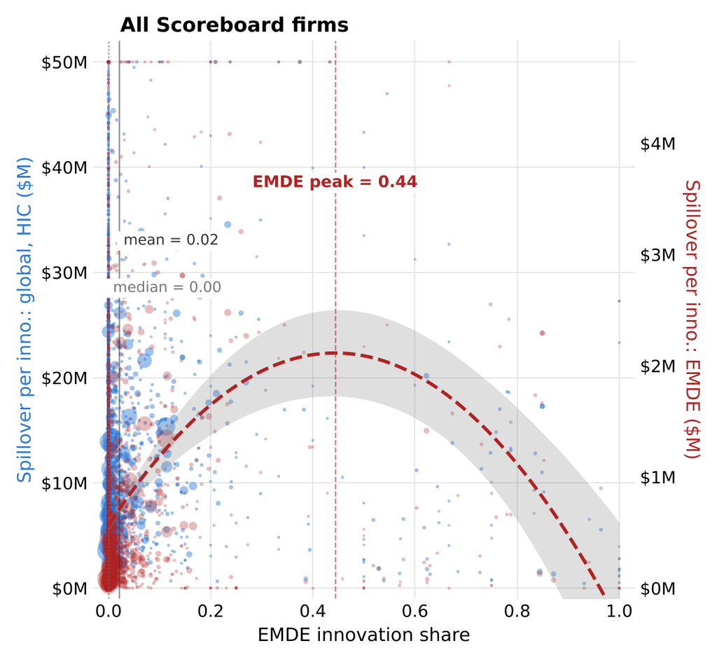

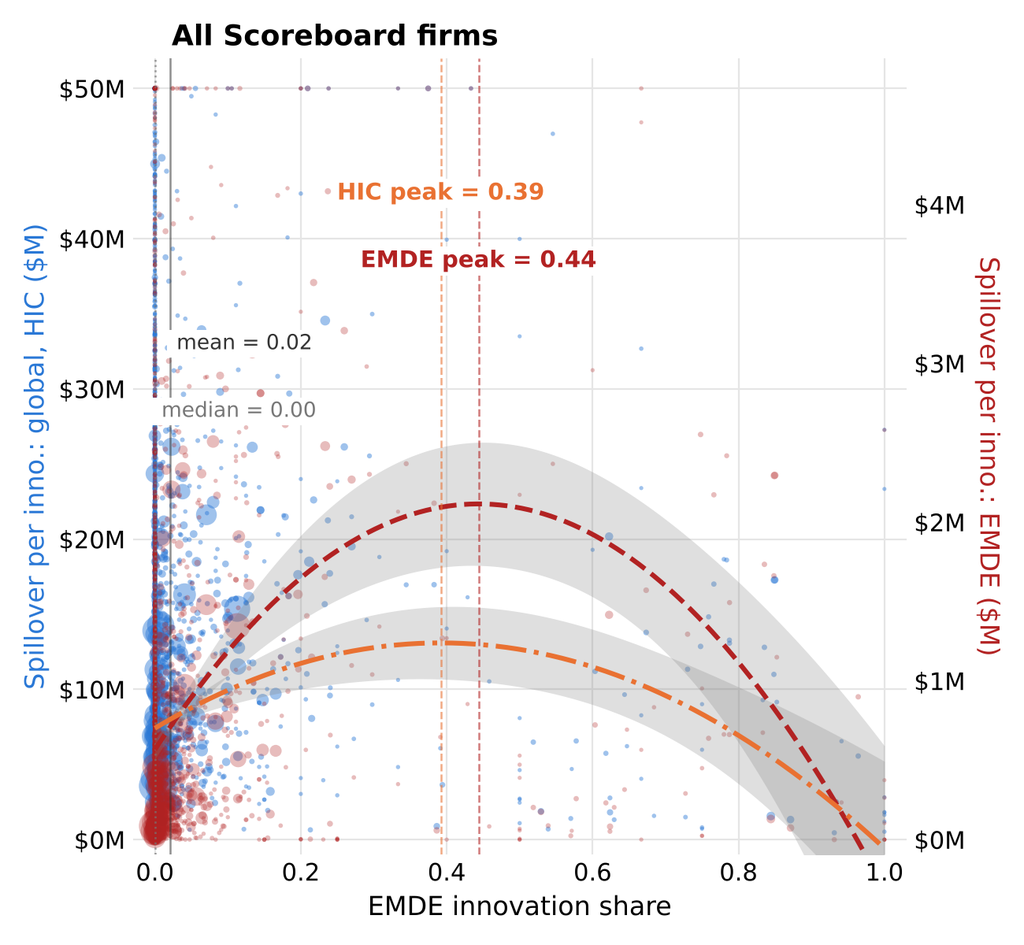

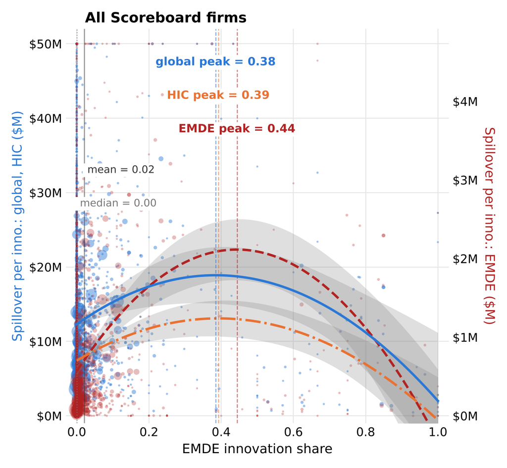

**Spillovers to EMDE rise over a wide range** as a firm’s innovations become more EMDE–HIC diverse — an inverted U peaking at an EMDE share of **0.44**

**HICs gain too:** spillovers to HIC follow the same inverted U, peaking at **0.39** — no dilution

## Why an inverted U? A model of knowledge diversity

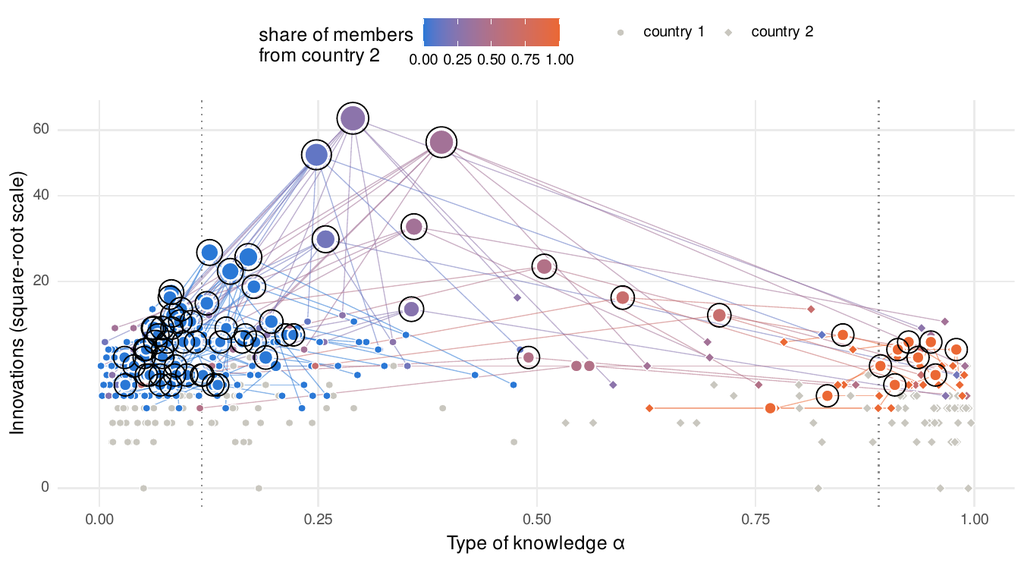

Innovators have a *type* of knowledge α; innovators from different countries cluster by type

Firms are collections of innovators (circles: successful attempts, coloured by the firm’s country-2 share)

Innovation attempts by more type-diverse innovators have a higher success probability

Firms can invest in a foreign lab = a bridge between more diverse knowledge stocks

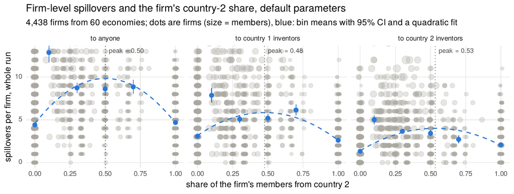

Firm-level spillovers peak at an interior share of country-2 innovators

[figure not shown]

Interactive version, every parameter adjustable:  
mondpanther.github.io/amodel

## Hitachi: a top global knowledge-spillover generator

Total **global** spillovers, 2013–22

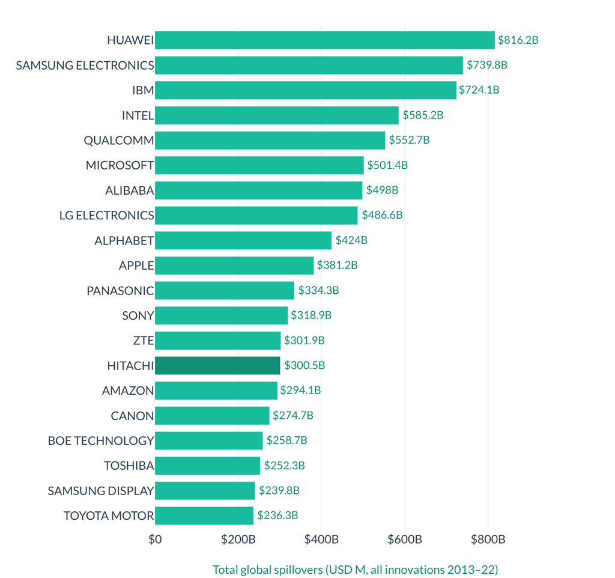

Total spillovers **to EMDE (incl. China)** — and EMDE share of global spillovers (◆)

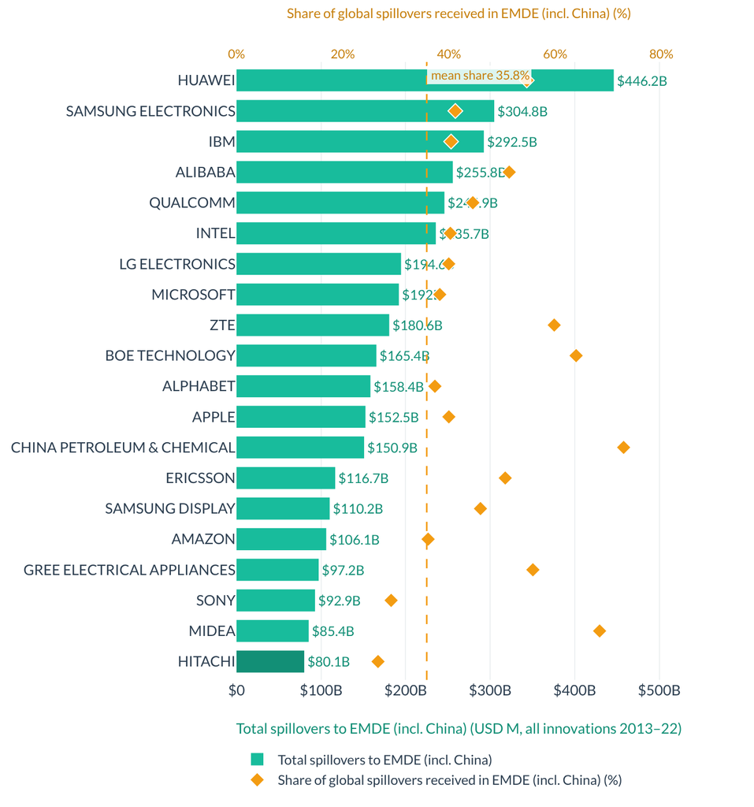

**#14 of 1,491** large R&D firms by total global spillover: **$300bn** from 36,269 innovations (the 10th-largest portfolio), $8.3M per innovation

#13 for spillovers to HICs; Hitachi’s 4,224 **green** innovations are its best: $10.2M each

**Only #20 for spillovers to EMDE** (#26 excluding China). Diamonds: the share of a firm’s global spillovers that reaches EMDE — **27% for Hitachi vs 36%** for the average large R&D firm (dashed line)

## Where Hitachi’s inventors are

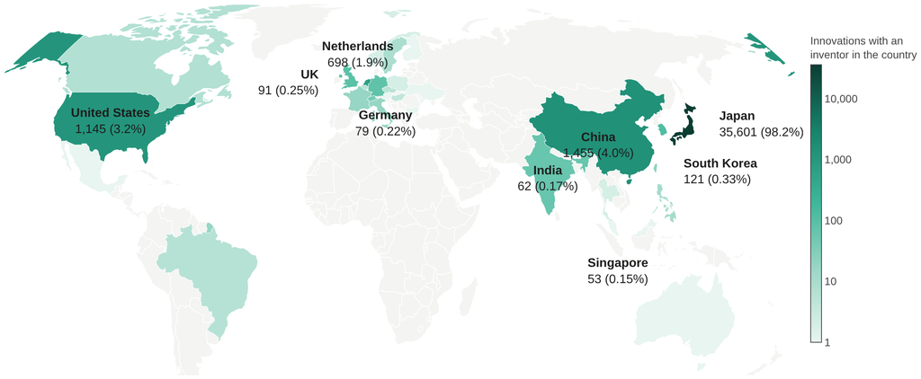

**98% of Hitachi’s 36,269 innovations have a Japanese inventor**; split equally across inventor countries, Japan accounts for 95% of the portfolio

Abroad: **China 1,455** (4.0%), **US 1,145**, Netherlands 698, Korea 121, UK 91, Germany 79

**EMDE outside China: 62 innovations with an Indian inventor, 11 Philippine, 6 Brazilian** — 0.2% of the portfolio, against 2.2% for the average large R&D firm

**Take-aways**

- EMDE innovation is scarce and, on average, of lower quality — but green EMDE innovation is as good as any, and it is mostly done **with HIC partners**
- Such partnerships are half of EMDE innovation but 2% of HIC innovation: **room to grow**
- More EMDE diversity raises a firm’s knowledge spillovers to EMDE **and** to HICs — a **win–win**, up to an EMDE share of ~40%
- **Hitachi:** a top-15 global spillover generator with an EMDE share of 0.2% — the diversification premium is still largely unclaimed
- **Policy implication:** HIC governments should support R&D activities by HIC firms in EMDE countries — the spillovers come back home

Thanks — r.martin@imperial.ac.uk

[figure not shown]

The paper: CEP Discussion Paper 2223  
[**Link ↗**](https://cep.lse.ac.uk/pubs/download/dp2223.pdf)

[figure not shown]

Spillover Champions — interactive, Hitachi view  
[**Link ↗**](https://mondpanther.github.io/kevceinsights/spillover-champions.html?scope=g&measure=ev&stat=mean&topn=20&minn=1000&green=all&hq=all&width=n&sectors=Electronic+%26+Electrical+Equipment&firms=HITACHI)

[figure not shown]

IFC report *Innovation in Green Technologies*  
[**Link ↗**](https://www.ifc.org/en/insights-reports/2025/innovation-in-green-technologies)

[figure not shown]

## Extra slides

[figure not shown]

## How do EMDE innovators manage this? Collaboration

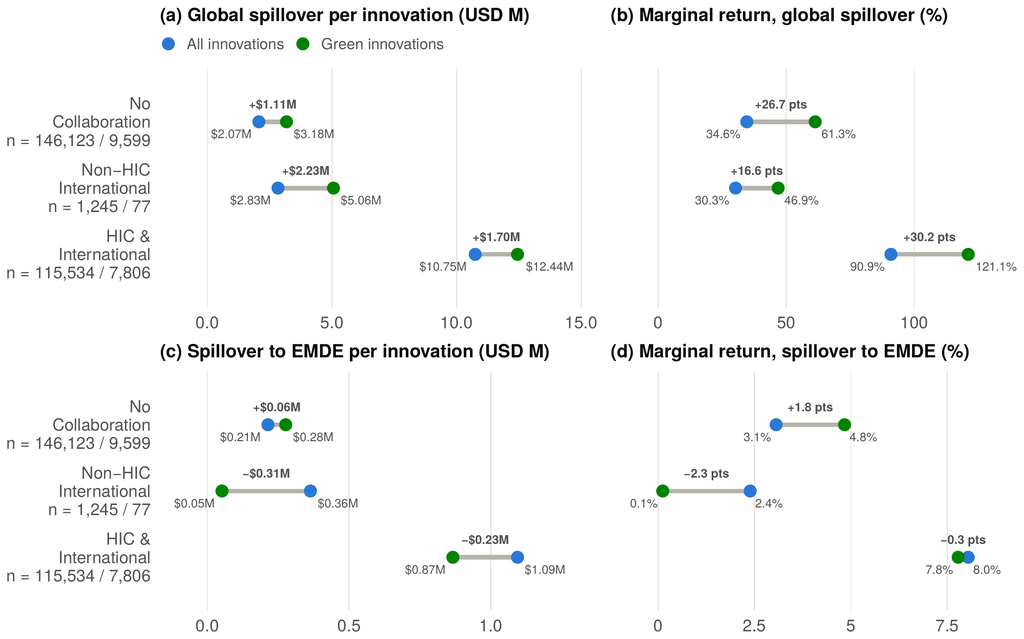

EMDE innovations made **together with HIC inventors** generate **$10.8M** of global spillover per innovation ($12.4M for green) …

… **five times** the $2.1M of EMDE innovations without international collaboration

And the spillovers **to EMDE** are highest for exactly these collaborations too (**$1.1M** vs $0.2M): no diversion of EMDE talent away from what matters for EMDE

## Half of EMDE innovation — but 2% of HIC innovation

EMDE–HIC collaboration With Chinese inventor Same income group National only

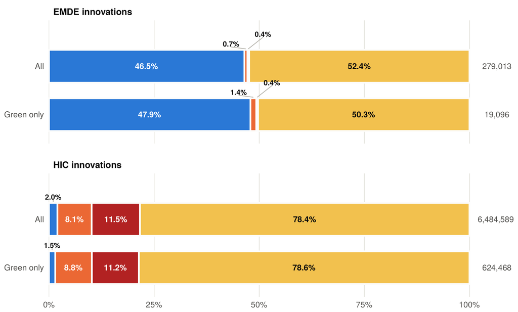

**Nearly half (46.5%) of all EMDE innovations** are collaborations with HIC inventors (47.9% for green)

**The view from HIC:** EMDE inventors appear in only **2.0%** of HIC innovations (1.5% green) — 78% of HIC innovations are purely national

## But: EMDE share and EMDE spillovers are still small

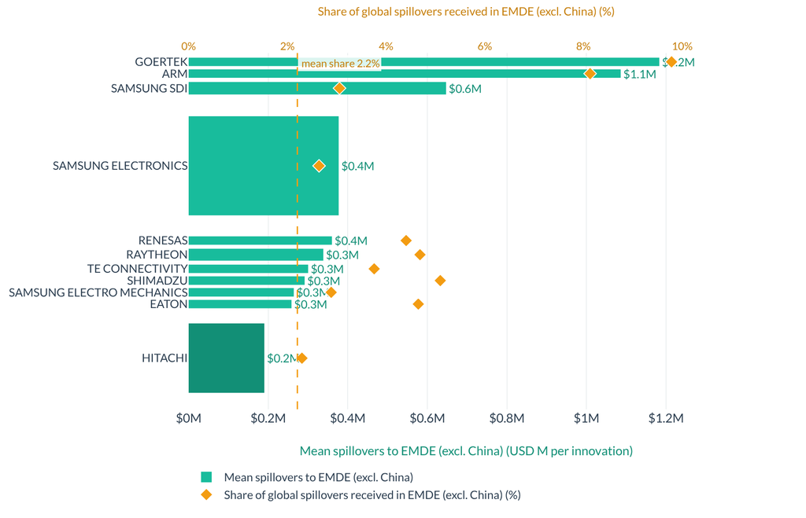

Only **0.19%** of Hitachi’s innovations involve an EMDE inventor — against a 2.2% Scoreboard average and the **38–44%** peak of the inverted U

[figure not shown]

Interactive: Spillover Champions, Hitachi view

## Hitachi on the inverted U

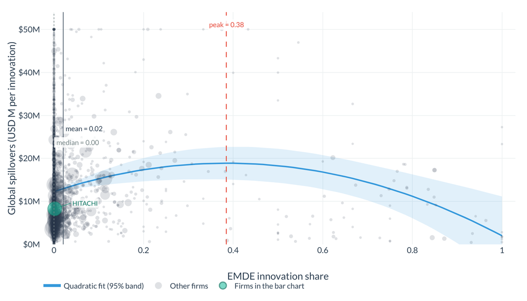

Hitachi sits at the **far left** of the curve, where the spillover gain from more EMDE diversity is **steepest**

The firm-level relationship implies that a one-SD move to a 12% EMDE share goes with **+$1.8M of HIC spillover and +$0.5M of EMDE spillover per innovation** — over a portfolio of 36,000 innovations

Where to start: green and adaptation technologies, where EMDE collaborations already perform best